# TP 2 : Analyse en composantes principales (ACP) avec FactoMineR sur les données decathlon

François Husson, S. Lèbre

# Importation du jeu de données

```r
decathlon <- read.table("../../decathlon.csv",
      header=TRUE, sep=";",dec=".", row.names=1, check.names=FALSE, fileEncoding="latin1")
```

`header=TRUE` : précise que le nom des variables est présent

`sep=";"` : précise que le séparateur de colonnes est le point-virgule (fréquent dans les fichiers csv, pour une tabulation il faudrait écrire `sep="\t"`)

`dec="."` : le séparateur de décimale est le point (parfois dans Excel on trouve la virgule)

`row.names=1` : précise que le nom des individus est dans la première colonne du tableau

`check.names=FALSE` : impose que le nom des colonnes soit pris tel que dans le fichier (sinon les espaces sont remplacés par des points et des X sont mis avant les nombres)

Il est important de s’assurer que l’importation a bien été effectuée, et notamment que les variables quantitatives sont bien considérées comme quantitatives et les variables qualitatives bien considérées comme qualitatives

# Analyse statistique univariée

```r
summary(decathlon)
```

```
##       100m          Longueur        Poids          Hauteur           400m
##  Min.   :10.44   Min.   :6.61   Min.   :12.68   Min.   :1.850   Min.   :46.81
##  1st Qu.:10.85   1st Qu.:7.03   1st Qu.:13.88   1st Qu.:1.920   1st Qu.:48.93
##  Median :10.98   Median :7.30   Median :14.57   Median :1.950   Median :49.40
##  Mean   :11.00   Mean   :7.26   Mean   :14.48   Mean   :1.977   Mean   :49.62
##  3rd Qu.:11.14   3rd Qu.:7.48   3rd Qu.:14.97   3rd Qu.:2.040   3rd Qu.:50.30
##  Max.   :11.64   Max.   :7.96   Max.   :16.36   Max.   :2.150   Max.   :53.20
##      110m H          Disque          Perche         Javelot
##  Min.   :13.97   Min.   :37.92   Min.   :4.200   Min.   :50.31
##  1st Qu.:14.21   1st Qu.:41.90   1st Qu.:4.500   1st Qu.:55.27
##  Median :14.48   Median :44.41   Median :4.800   Median :58.36
##  Mean   :14.61   Mean   :44.33   Mean   :4.762   Mean   :58.32
##  3rd Qu.:14.98   3rd Qu.:46.07   3rd Qu.:4.920   3rd Qu.:60.89
##  Max.   :15.67   Max.   :51.65   Max.   :5.400   Max.   :70.52
##      1500m         Classement        Points     Competition
##  Min.   :262.1   Min.   : 1.00   Min.   :7313   Length:41
##  1st Qu.:271.0   1st Qu.: 6.00   1st Qu.:7802   Class :character
##  Median :278.1   Median :11.00   Median :8021   Mode  :character
##  Mean   :279.0   Mean   :12.12   Mean   :8005
##  3rd Qu.:285.1   3rd Qu.:18.00   3rd Qu.:8122
##  Max.   :317.0   Max.   :28.00   Max.   :8893
```

```r
Xquanti<-decathlon[,-c(13)]
summary(Xquanti)
```

```
##       100m          Longueur        Poids          Hauteur           400m
##  Min.   :10.44   Min.   :6.61   Min.   :12.68   Min.   :1.850   Min.   :46.81
##  1st Qu.:10.85   1st Qu.:7.03   1st Qu.:13.88   1st Qu.:1.920   1st Qu.:48.93
##  Median :10.98   Median :7.30   Median :14.57   Median :1.950   Median :49.40
##  Mean   :11.00   Mean   :7.26   Mean   :14.48   Mean   :1.977   Mean   :49.62
##  3rd Qu.:11.14   3rd Qu.:7.48   3rd Qu.:14.97   3rd Qu.:2.040   3rd Qu.:50.30
##  Max.   :11.64   Max.   :7.96   Max.   :16.36   Max.   :2.150   Max.   :53.20
##      110m H          Disque          Perche         Javelot
##  Min.   :13.97   Min.   :37.92   Min.   :4.200   Min.   :50.31
##  1st Qu.:14.21   1st Qu.:41.90   1st Qu.:4.500   1st Qu.:55.27
##  Median :14.48   Median :44.41   Median :4.800   Median :58.36
##  Mean   :14.61   Mean   :44.33   Mean   :4.762   Mean   :58.32
##  3rd Qu.:14.98   3rd Qu.:46.07   3rd Qu.:4.920   3rd Qu.:60.89
##  Max.   :15.67   Max.   :51.65   Max.   :5.400   Max.   :70.52
##      1500m         Classement        Points
##  Min.   :262.1   Min.   : 1.00   Min.   :7313
##  1st Qu.:271.0   1st Qu.: 6.00   1st Qu.:7802
##  Median :278.1   Median :11.00   Median :8021
##  Mean   :279.0   Mean   :12.12   Mean   :8005
##  3rd Qu.:285.1   3rd Qu.:18.00   3rd Qu.:8122
##  Max.   :317.0   Max.   :28.00   Max.   :8893
```

```r
#y a t-il des variables manquantes ?
sum(is.na(Xquanti)) #reponse
```

```
## [1] 0
```

```r
apply(Xquanti, 2,var)
```

```
##         100m     Longueur        Poids      Hauteur         400m       110m H
## 6.918110e-02 1.001100e-01 6.796812e-01 7.912195e-03 1.330449e+00 2.225849e-01
##       Disque       Perche      Javelot        1500m   Classement       Points
## 1.140984e+01 7.728390e-02 2.329819e+01 1.362647e+02 6.270976e+01 1.172276e+05
```

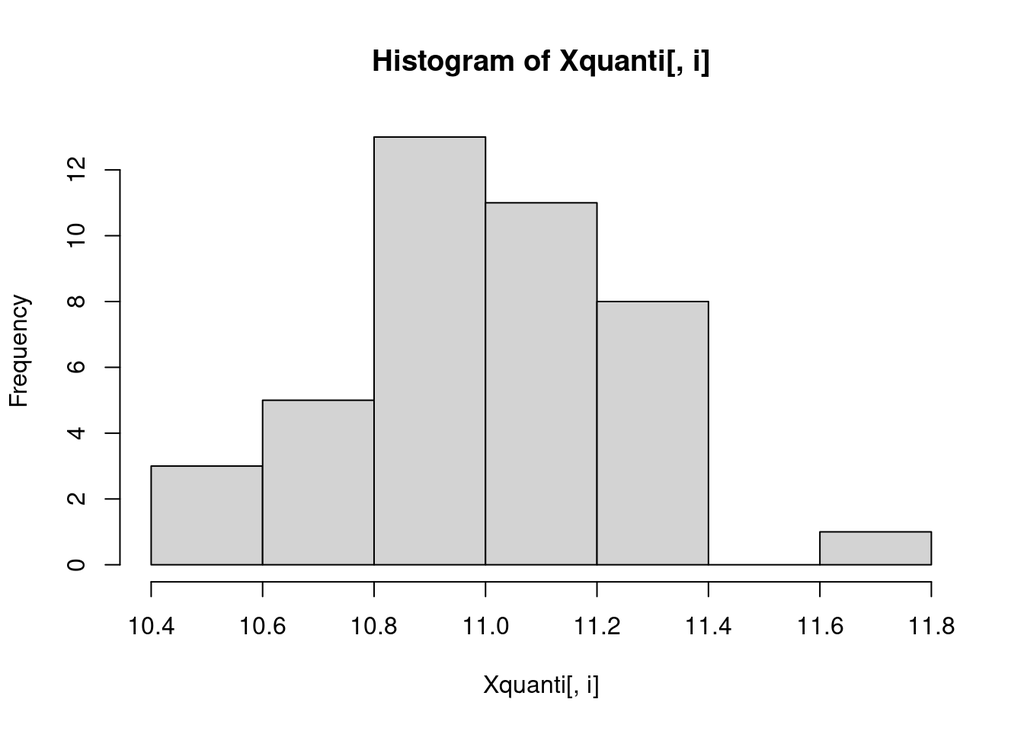

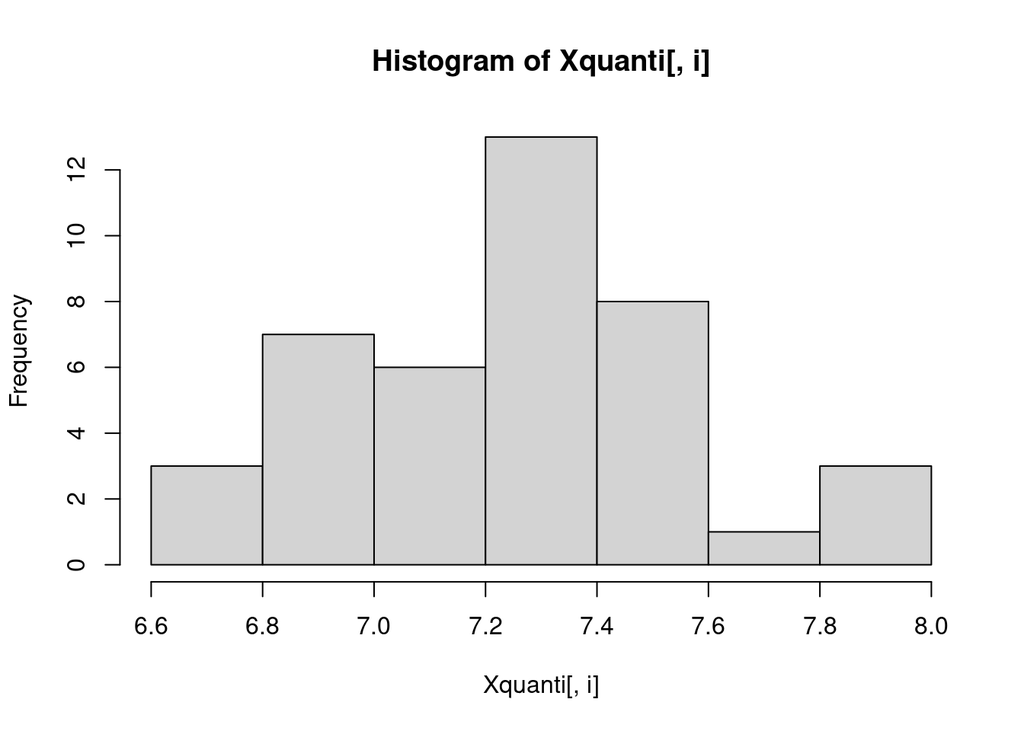

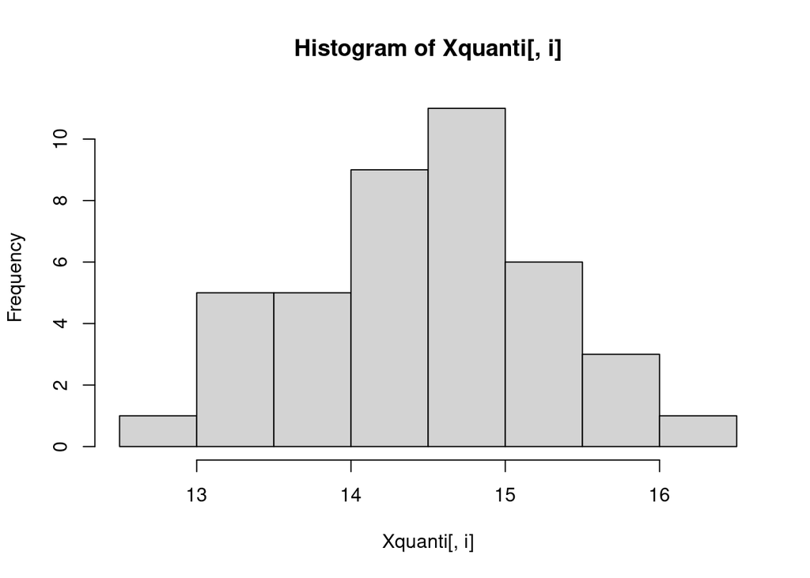

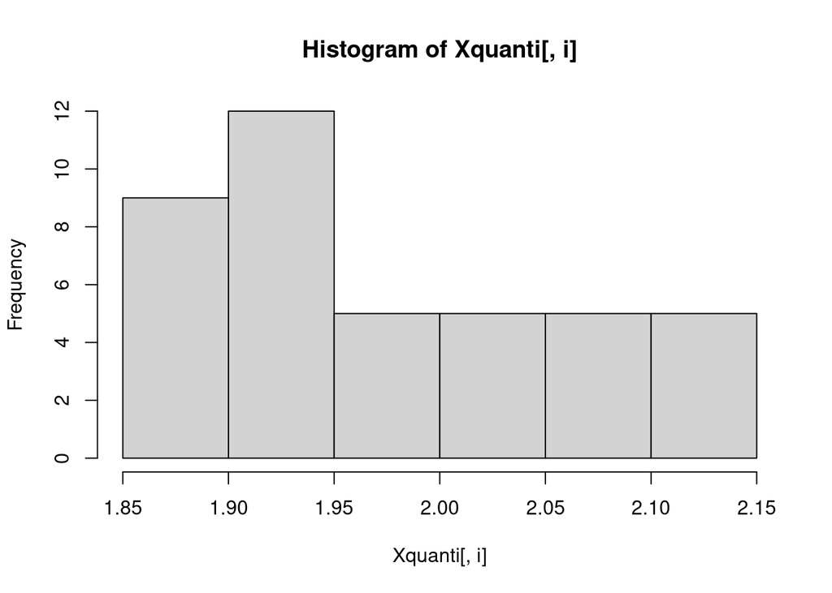

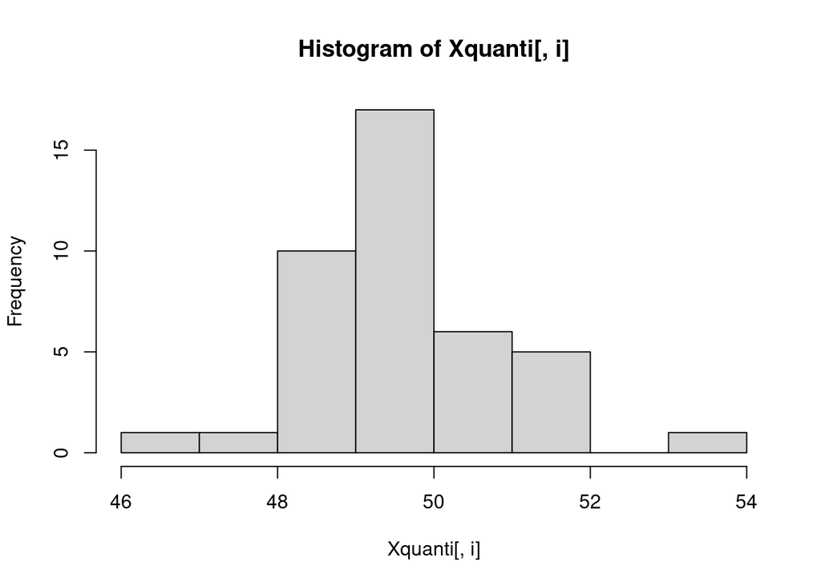

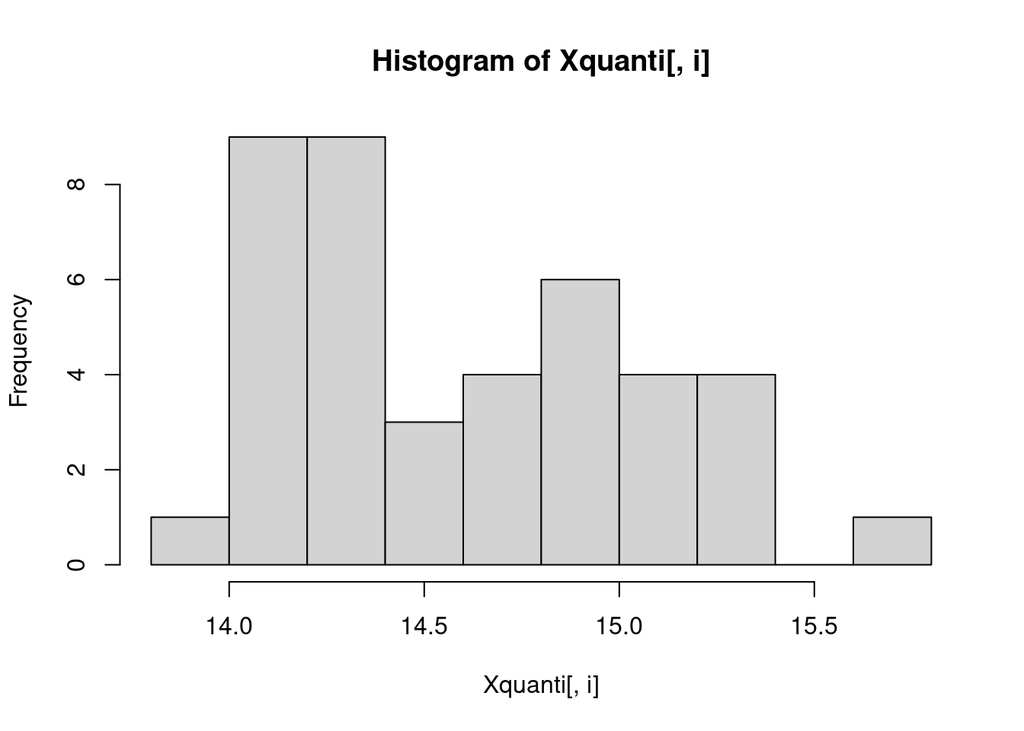

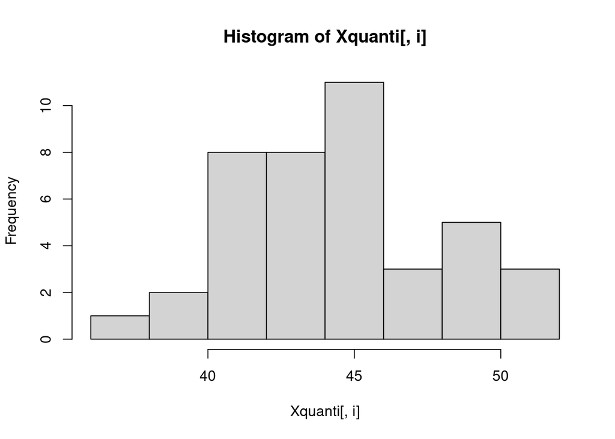

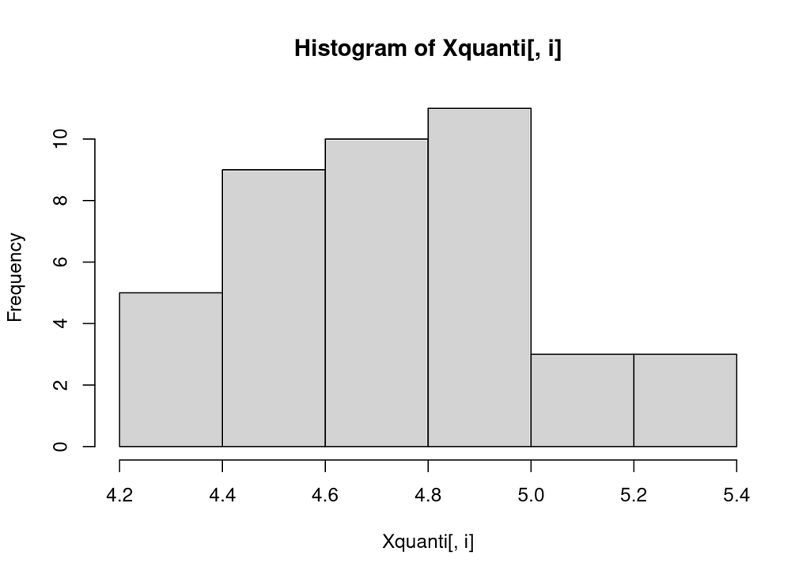

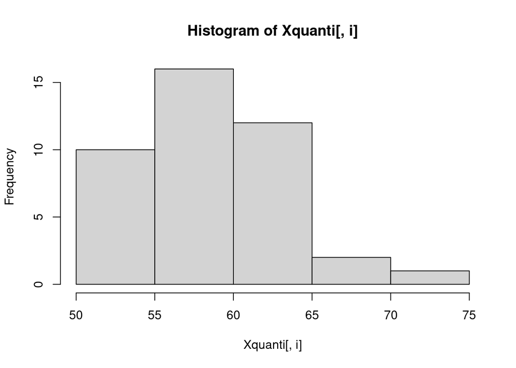

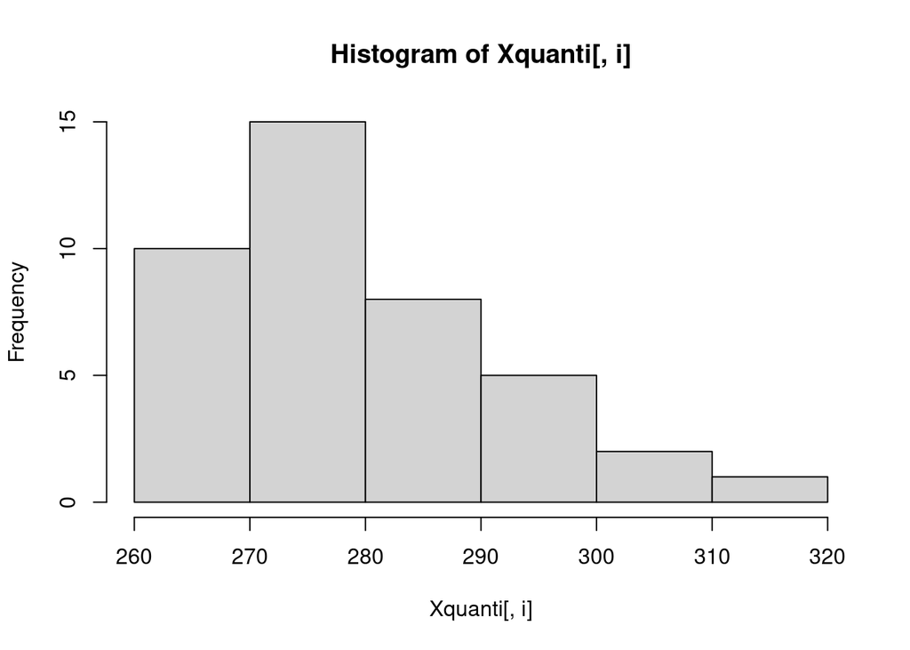

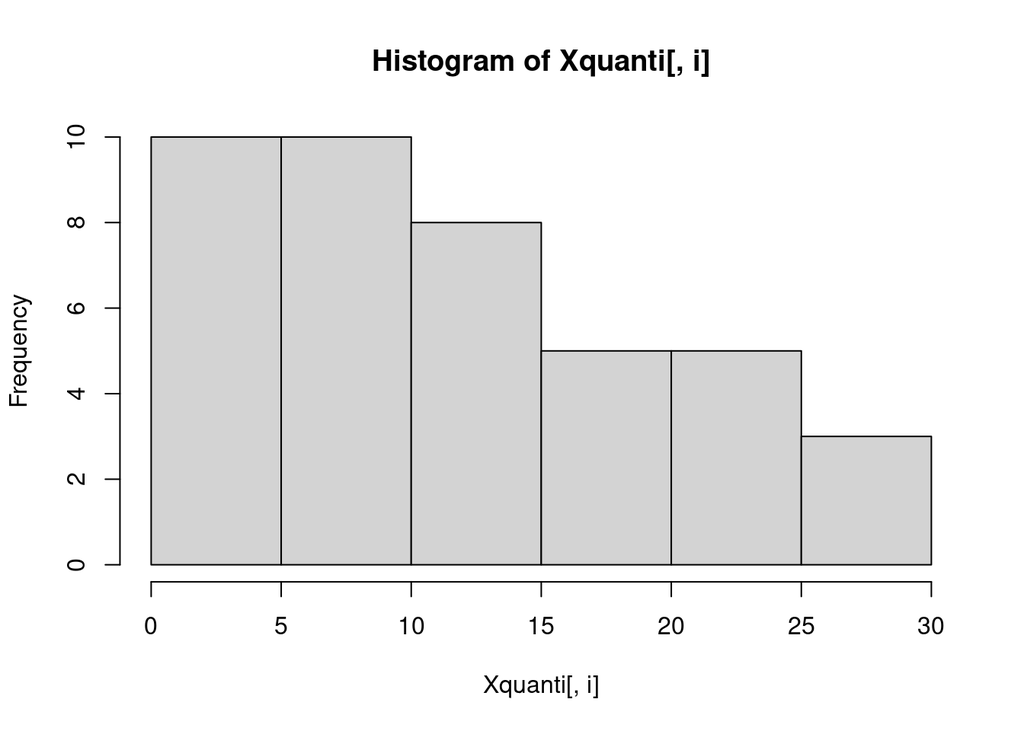

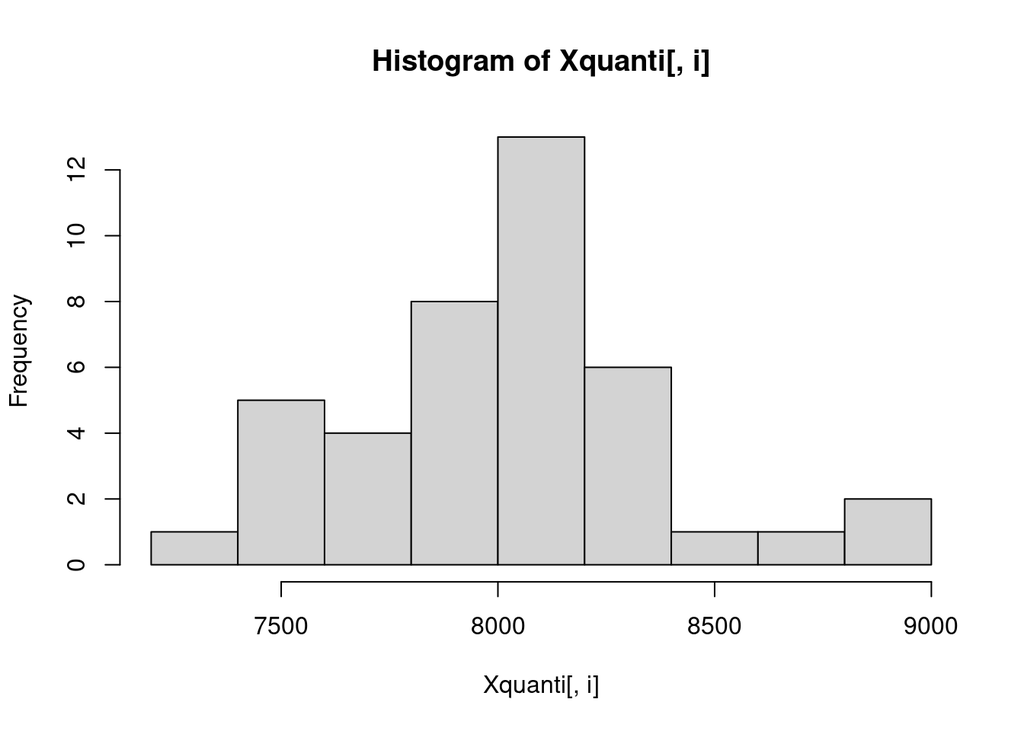

```r
for(i in 1:12){
  hist(Xquanti[,i])
}
```

# Analyse statistique bivariée

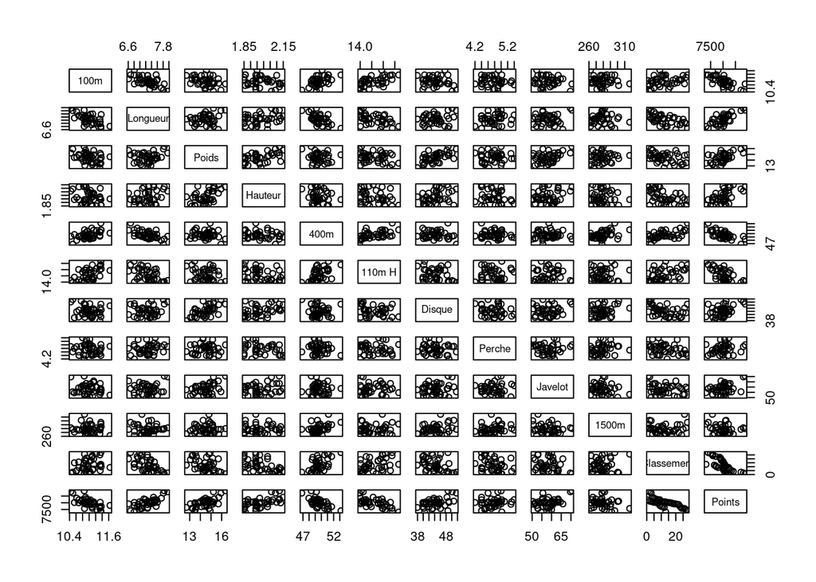

```r
plot(Xquanti)
```

La corrélation de Pearson entre deux variables $X$ et $Y$ est donnée par :

$$r = \frac{\sum (X_i - \bar{X})(Y_i - \bar{Y})}{\sqrt{\sum (X_i -
\bar{X})^2 \sum (Y_i - \bar{Y})^2}}$$

où : - $r$ est le coefficient de corrélation, - $X_i$ et $Y_i$ sont les valeurs des variables, - $\bar{X}$ et $\bar{Y}$ sont les moyennes des variables.

*(cf : [fiche de revision](https://github.com/akhythmetic/mms/blob/master/fiche_revision/ran_correlation.md))*

```r
matrice_cor <- cor(Xquanti)
matrice_cor
```

```
##                   100m    Longueur       Poids     Hauteur         400m
## 100m        1.00000000 -0.59867767 -0.35648227 -0.24625292  0.520298155
## Longueur   -0.59867767  1.00000000  0.18330436  0.29464444 -0.602062618
## Poids      -0.35648227  0.18330436  1.00000000  0.48921153 -0.138432919
## Hauteur    -0.24625292  0.29464444  0.48921153  1.00000000 -0.187956928
## 400m        0.52029815 -0.60206262 -0.13843292 -0.18795693  1.000000000
## 110m H      0.57988893 -0.50541009 -0.25161571 -0.28328909  0.547987756
## Disque     -0.22170757  0.19431009  0.61576810  0.36921834 -0.117879365
## Perche     -0.08253683  0.20401411  0.06118185 -0.15618074 -0.079292469
## Javelot    -0.15774645  0.11975893  0.37495551  0.17188009  0.004232096
## 1500m      -0.06054645 -0.03368613  0.11580306 -0.04490252  0.408106432
## Classement  0.29670366 -0.60405452 -0.36996958 -0.49276873  0.562118543
## Points     -0.68427243  0.72513490  0.62738936  0.57670316 -0.666939955
##                  110m H     Disque       Perche      Javelot       1500m
## 100m        0.579888931 -0.2217076 -0.082536834 -0.157746452 -0.06054645
## Longueur   -0.505410086  0.1943101  0.204014112  0.119758933 -0.03368613
## Poids      -0.251615714  0.6157681  0.061181853  0.374955509  0.11580306
## Hauteur    -0.283289090  0.3692183 -0.156180742  0.171880092 -0.04490252
## 400m        0.547987756 -0.1178794 -0.079292469  0.004232096  0.40810643
## 110m H      1.000000000 -0.3262010 -0.002703885  0.008743251  0.03754024
## Disque     -0.326200961  1.0000000 -0.150072400  0.157889799  0.25817510
## Perche     -0.002703885 -0.1500724  1.000000000 -0.030000603  0.24744778
## Javelot     0.008743251  0.1578898 -0.030000603  1.000000000 -0.18039313
## 1500m       0.037540240  0.2581751  0.247447780 -0.180393128  1.00000000
## Classement  0.439102281 -0.3891251 -0.320379567 -0.208094646  0.08989781
## Points     -0.644460200  0.4841830  0.197436342  0.422393176 -0.19434860
##             Classement     Points
## 100m        0.29670366 -0.6842724
## Longueur   -0.60405452  0.7251349
## Poids      -0.36996958  0.6273894
## Hauteur    -0.49276873  0.5767032
## 400m        0.56211854 -0.6669400
## 110m H      0.43910228 -0.6444602
## Disque     -0.38912515  0.4841830
## Perche     -0.32037957  0.1974363
## Javelot    -0.20809465  0.4223932
## 1500m       0.08989781 -0.1943486
## Classement  1.00000000 -0.7391835
## Points     -0.73918347  1.0000000
```

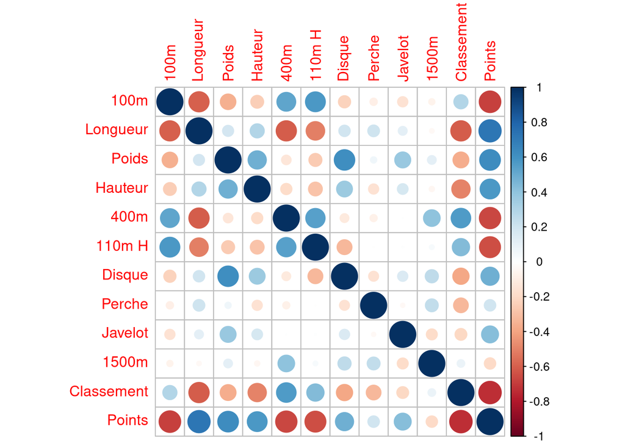

```r
install.packages("corrplot")
library(corrplot)
corrplot(matrice_cor)
```

### Correlation min et max

```r
max(matrice_cor)
```

```
## [1] 1
```

```r
min(matrice_cor)
```

```
## [1] -0.7391835
```

### Paires de correlation sup à 0.5

```r
(sum(matrice_cor > 0.5)-12)/2
```

```
## [1] 8
```

# ACP

## Chargement de FactoMineR

```r
library(FactoMineR)
```

## L’ACP avec uniquement des éléments (lignes et variables) actifs

Choisir uniquement les colonnes associées aux différentes épreuves.

```r
 epreuve <- Xquanti[, 1:10]
```

```r
res <- PCA(epreuve)
```

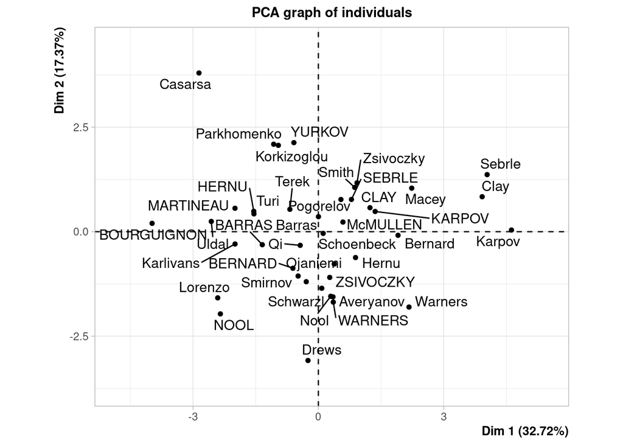

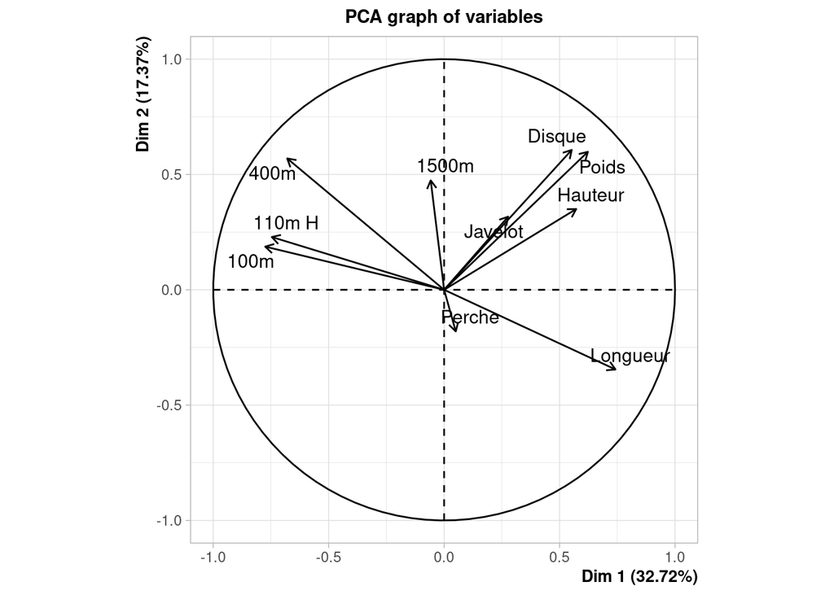

**Question 1** Quelles sont les 2 graphiques donnés en sortie de l’appel à la fonction `PCA()` ?

- Nuages des inndividus
- Cercles des correlations (variables)

**Question 2** Quelle est la part de variance expliquée par le 1er axe ? par le 2ème axe ?

- Le 1ere axe porte 32.72% de la variance
- Le 2eme axe porte 17.37% de la variance

On peut obtenir un résumé des principaux résultats en utilisant la fonction `summary`.

**Question 3** : Utiliser la fonction `summary` sur l’objet utilisé pour stocker les résulats de l’ACP.

-> val. propres

-> Individus

-> Variables

```r
summary(res)
```

```
##
## Call:
## PCA(X = epreuve)
##
##
## Eigenvalues
##                        Dim.1   Dim.2   Dim.3   Dim.4   Dim.5   Dim.6   Dim.7
## Variance               3.272   1.737   1.405   1.057   0.685   0.599   0.451
## % of var.             32.719  17.371  14.049  10.569   6.848   5.993   4.512
## Cumulative % of var.  32.719  50.090  64.140  74.708  81.556  87.548  92.061
##                        Dim.8   Dim.9  Dim.10
## Variance               0.397   0.215   0.182
## % of var.              3.969   2.148   1.822
## Cumulative % of var.  96.030  98.178 100.000
##
## Individuals (the 10 first)
##               Dist    Dim.1    ctr   cos2    Dim.2    ctr   cos2    Dim.3
## Sebrle    |  4.843 |  4.038 12.158  0.695 |  1.366  2.619  0.080 | -0.290
## Clay      |  4.647 |  3.919 11.451  0.711 |  0.837  0.984  0.032 |  0.231
## Karpov    |  5.006 |  4.620 15.911  0.852 |  0.040  0.002  0.000 | -0.042
## Macey     |  3.434 |  2.233  3.719  0.423 |  1.042  1.524  0.092 | -1.864
## Warners   |  2.979 |  2.168  3.505  0.530 | -1.803  4.565  0.366 |  0.851
## Zsivoczky |  2.566 |  0.925  0.638  0.130 |  1.169  1.918  0.207 | -1.477
## Hernu     |  1.824 |  0.889  0.589  0.238 | -0.618  0.537  0.115 | -0.898
## Nool      |  3.098 |  0.295  0.065  0.009 | -1.546  3.354  0.249 |  1.355
## Bernard   |  2.827 |  1.906  2.709  0.455 | -0.086  0.010  0.001 | -0.757
## Schwarzl  |  1.971 |  0.081  0.005  0.002 | -1.353  2.572  0.472 |  0.822
##              ctr   cos2
## Sebrle     0.146  0.004 |
## Clay       0.093  0.002 |
## Karpov     0.003  0.000 |
## Macey      6.034  0.295 |
## Warners    1.257  0.082 |
## Zsivoczky  3.790  0.332 |
## Hernu      1.401  0.242 |
## Nool       3.189  0.191 |
## Bernard    0.995  0.072 |
## Schwarzl   1.174  0.174 |
##
## Variables
##              Dim.1    ctr   cos2    Dim.2    ctr   cos2    Dim.3    ctr   cos2
## 100m      | -0.775 18.344  0.600 |  0.187  2.016  0.035 | -0.184  2.420  0.034
## Longueur  |  0.742 16.822  0.550 | -0.345  6.869  0.119 |  0.182  2.363  0.033
## Poids     |  0.623 11.844  0.388 |  0.598 20.607  0.358 | -0.023  0.039  0.001
## Hauteur   |  0.572  9.998  0.327 |  0.350  7.064  0.123 | -0.260  4.794  0.067
## 400m      | -0.680 14.116  0.462 |  0.569 18.666  0.324 |  0.131  1.230  0.017
## 110m H    | -0.746 17.020  0.557 |  0.229  3.013  0.052 | -0.093  0.611  0.009
## Disque    |  0.552  9.328  0.305 |  0.606 21.162  0.368 |  0.043  0.131  0.002
## Perche    |  0.050  0.077  0.003 | -0.180  1.873  0.033 |  0.692 34.061  0.479
## Javelot   |  0.277  2.347  0.077 |  0.317  5.784  0.100 | -0.390 10.807  0.152
## 1500m     | -0.058  0.103  0.003 |  0.474 12.946  0.225 |  0.782 43.543  0.612
##
## 100m      |
## Longueur  |
## Poids     |
## Hauteur   |
## 400m      |
## 110m H    |
## Disque    |
## Perche    |
## Javelot   |
## 1500m     |
```

**Bonus** Representer graphiquement la valeur de la variance expliquée pour tous les axes

```r
res$eig
```

```
##         eigenvalue percentage of variance cumulative percentage of variance
## comp 1   3.2719055              32.719055                          32.71906
## comp 2   1.7371310              17.371310                          50.09037
## comp 3   1.4049167              14.049167                          64.13953
## comp 4   1.0568504              10.568504                          74.70804
## comp 5   0.6847735               6.847735                          81.55577
## comp 6   0.5992687               5.992687                          87.54846
## comp 7   0.4512353               4.512353                          92.06081
## comp 8   0.3968766               3.968766                          96.02958
## comp 9   0.2148149               2.148149                          98.17773
## comp 10  0.1822275               1.822275                         100.00000
```

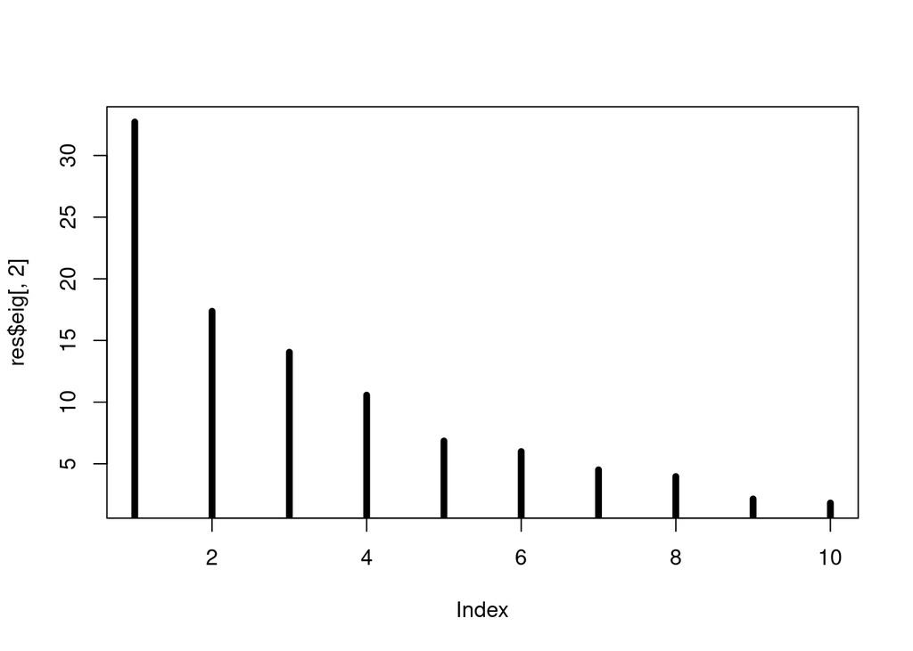

```r
plot(res$eig[,2],type="h",lwd=5)
```

**Question 3** : Quelle est la part de variance expliquée par les 2 premiers axes ?

- 50%

**Question 4** : Quelle est la part de variance expliquée par le 3ème axe ?

- 14%
- => pour chercher 75% de la variance il faut prendre 4 axes

### Préciser le nombre de dimensions

Nous pouvons demander à avoir les résultats sur les 2 premières dimensions pour éviter d’avoir des tableaux trop grands grâce au paramètre `ncp` qui indique le nombre de composantes principales souhaitées (par défaut, la fonction retourne les résultats des 3 premières dimensions).

**Question 5** : Dans la fonction `summary` ci-dessous, restreindre les sorties résumées au 2 premières dimensions.

```r
summary <- summary(res, ncp=2)
```

**Question 6** : Quelles sont les variables avec les coordonnées les plus extrêmes sur l’axe 1 ? sur l’axe 2 ?

```r
var_acp <- res$var$coord # extaction tableau coordonnée variable
dim1_max <- rownames(var_acp)[which.max(var_acp[,1])]
dim1_min <- rownames(var_acp)[which.min(var_acp[,1])]
dim2_max <- rownames(var_acp)[which.max(var_acp[,2])]
dim2_min <- rownames(var_acp)[which.min(var_acp[,2])]

extr_frame <- data.frame(
  Axe = c("Dim 1", "Dim 2"),
  Max = c(dim1_max, dim2_max),
  Min = c(dim1_min, dim2_min)
)

extr_frame
```

```
##     Axe      Max      Min
## 1 Dim 1 Longueur     100m
## 2 Dim 2   Disque Longueur
```

## L’ACP avec des variables supplémentaires (quantitatives ou qualitatives)

Il est possible de représenter des variables sur le cercle des corrélations, alors qu’elles n’ont pas été utilisées pour construire les axes de l’ACP, grâce aux paramètres `quanti.sup=` et `quali.sup=` :

**Question 6** : Ajouter les variables des colonnes 11 et 12 en variables supplémentaires. Afficher le résumé pour les 2 premières dimensions. Qu’observez-vous ?

```r
res_pca_11_12 <- PCA(
  Xquanti, #data
  quali.sup = 11,
  quanti.sup = 12
)
```

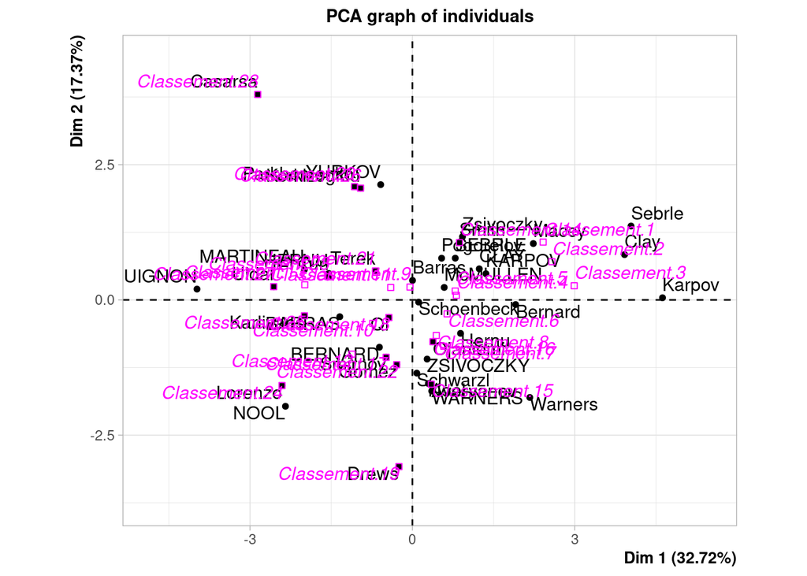

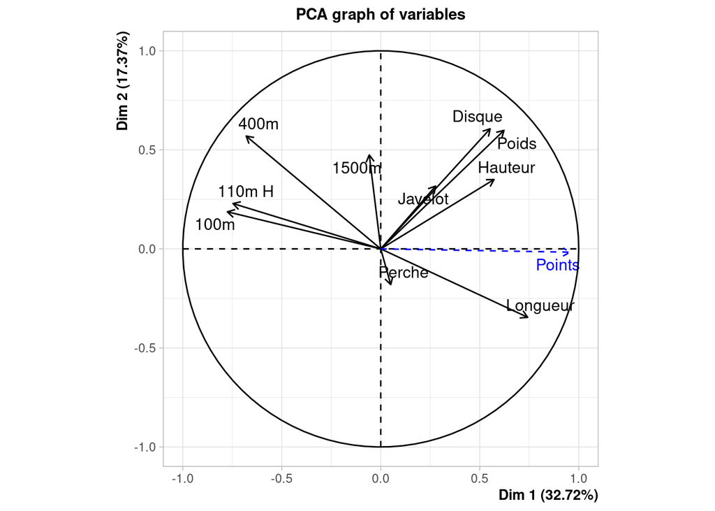

Les points sont fortement correlé avec la dimention 1. et la positivité sur les deux axes est liée avec le classement

**Question 7** : Ajouter la variable de la colonne 13 en variable supplémentaire. Afficher le résumé pour les 2 premières dimensions. Qu’observez-vous ?

```r
res_pca_11_12_13 <- PCA(
  decathlon[,-11], #data
  quali.sup = 12,
  quanti.sup = 11
)
```

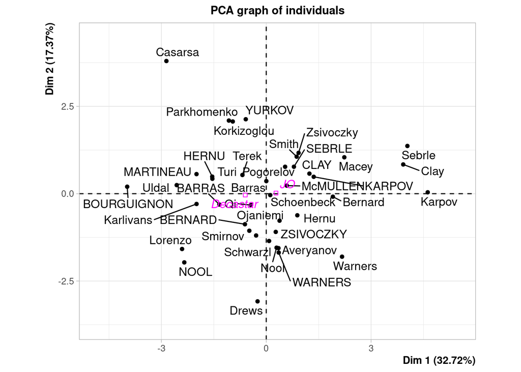

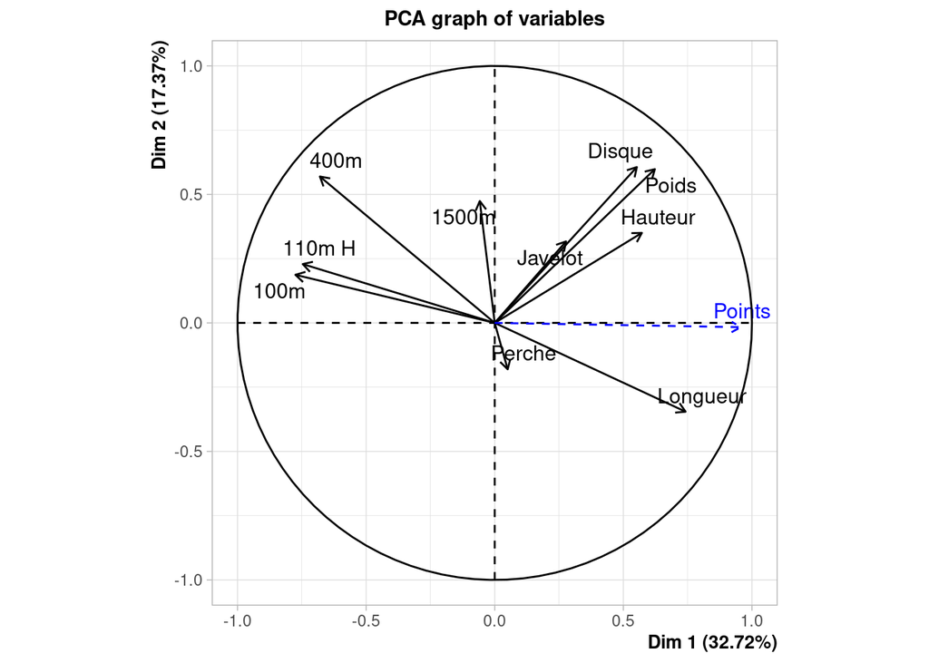

```r
summary(res_pca_11_12_13, ncp=2)
```

```
##
## Call:
## PCA(X = decathlon[, -11], quanti.sup = 11, quali.sup = 12)
##
##
## Eigenvalues
##                        Dim.1   Dim.2   Dim.3   Dim.4   Dim.5   Dim.6   Dim.7
## Variance               3.272   1.737   1.405   1.057   0.685   0.599   0.451
## % of var.             32.719  17.371  14.049  10.569   6.848   5.993   4.512
## Cumulative % of var.  32.719  50.090  64.140  74.708  81.556  87.548  92.061
##                        Dim.8   Dim.9  Dim.10
## Variance               0.397   0.215   0.182
## % of var.              3.969   2.148   1.822
## Cumulative % of var.  96.030  98.178 100.000
##
## Individuals (the 10 first)
##               Dist    Dim.1    ctr   cos2    Dim.2    ctr   cos2
## Sebrle    |  4.843 |  4.038 12.158  0.695 |  1.366  2.619  0.080 |
## Clay      |  4.647 |  3.919 11.451  0.711 |  0.837  0.984  0.032 |
## Karpov    |  5.006 |  4.620 15.911  0.852 |  0.040  0.002  0.000 |
## Macey     |  3.434 |  2.233  3.719  0.423 |  1.042  1.524  0.092 |
## Warners   |  2.979 |  2.168  3.505  0.530 | -1.803  4.565  0.366 |
## Zsivoczky |  2.566 |  0.925  0.638  0.130 |  1.169  1.918  0.207 |
## Hernu     |  1.824 |  0.889  0.589  0.238 | -0.618  0.537  0.115 |
## Nool      |  3.098 |  0.295  0.065  0.009 | -1.546  3.354  0.249 |
## Bernard   |  2.827 |  1.906  2.709  0.455 | -0.086  0.010  0.001 |
## Schwarzl  |  1.971 |  0.081  0.005  0.002 | -1.353  2.572  0.472 |
##
## Variables
##              Dim.1    ctr   cos2    Dim.2    ctr   cos2
## 100m      | -0.775 18.344  0.600 |  0.187  2.016  0.035 |
## Longueur  |  0.742 16.822  0.550 | -0.345  6.869  0.119 |
## Poids     |  0.623 11.844  0.388 |  0.598 20.607  0.358 |
## Hauteur   |  0.572  9.998  0.327 |  0.350  7.064  0.123 |
## 400m      | -0.680 14.116  0.462 |  0.569 18.666  0.324 |
## 110m H    | -0.746 17.020  0.557 |  0.229  3.013  0.052 |
## Disque    |  0.552  9.328  0.305 |  0.606 21.162  0.368 |
## Perche    |  0.050  0.077  0.003 | -0.180  1.873  0.033 |
## Javelot   |  0.277  2.347  0.077 |  0.317  5.784  0.100 |
## 1500m     | -0.058  0.103  0.003 |  0.474 12.946  0.225 |
##
## Supplementary continuous variable
##              Dim.1   cos2    Dim.2   cos2
## Points    |  0.956  0.914 | -0.017  0.000 |
##
## Supplementary categories
##               Dist    Dim.1   cos2 v.test    Dim.2   cos2 v.test
## Decastar  |  0.946 | -0.600  0.403 -1.430 | -0.038  0.002 -0.123 |
## JO        |  0.439 |  0.279  0.403  1.430 |  0.017  0.002  0.123 |
```

### Pour imprimer les résultats dans un fichier :

```r
summary(res_pca_11_12_13, nbelements=Inf, file="essai.txt")
```

## Description des dimensions

**Question 8** : Décrire la sortie de la commande ci-dessous.

```r
dimdesc(res)
```

```
## $Dim.1
##
## Link between the variable and the continuous variables (R-square)
## =================================================================================
##          correlation      p.value
## Longueur   0.7418997 2.849886e-08
## Poids      0.6225026 1.388321e-05
## Hauteur    0.5719453 9.362285e-05
## Disque     0.5524665 1.802220e-04
## 400m      -0.6796099 1.028175e-06
## 110m H    -0.7462453 2.136962e-08
## 100m      -0.7747198 2.778467e-09
##
## $Dim.2
##
## Link between the variable and the continuous variables (R-square)
## =================================================================================
##          correlation      p.value
## Disque     0.6063134 2.650745e-05
## Poids      0.5983033 3.603567e-05
## 400m       0.5694378 1.020941e-04
## 1500m      0.4742238 1.734405e-03
## Hauteur    0.3502936 2.475025e-02
## Javelot    0.3169891 4.344974e-02
## Longueur  -0.3454213 2.696969e-02
##
## $Dim.3
##
## Link between the variable and the continuous variables (R-square)
## =================================================================================
##         correlation      p.value
## 1500m     0.7821428 1.554450e-09
## Perche    0.6917567 5.480172e-07
## Javelot  -0.3896554 1.179331e-02
```

**Question 9** : Que permet l’option `proba=0.2`?

```r
dimdesc(res, proba=0.2)
```

```
## $Dim.1
##
## Link between the variable and the continuous variables (R-square)
## =================================================================================
##          correlation      p.value
## Longueur   0.7418997 2.849886e-08
## Poids      0.6225026 1.388321e-05
## Hauteur    0.5719453 9.362285e-05
## Disque     0.5524665 1.802220e-04
## Javelot    0.2771108 7.942460e-02
## 400m      -0.6796099 1.028175e-06
## 110m H    -0.7462453 2.136962e-08
## 100m      -0.7747198 2.778467e-09
##
## $Dim.2
##
## Link between the variable and the continuous variables (R-square)
## =================================================================================
##          correlation      p.value
## Disque     0.6063134 2.650745e-05
## Poids      0.5983033 3.603567e-05
## 400m       0.5694378 1.020941e-04
## 1500m      0.4742238 1.734405e-03
## Hauteur    0.3502936 2.475025e-02
## Javelot    0.3169891 4.344974e-02
## 110m H     0.2287933 1.501925e-01
## Longueur  -0.3454213 2.696969e-02
##
## $Dim.3
##
## Link between the variable and the continuous variables (R-square)
## =================================================================================
##         correlation      p.value
## 1500m     0.7821428 1.554450e-09
## Perche    0.6917567 5.480172e-07
## Hauteur  -0.2595119 1.013160e-01
## Javelot  -0.3896554 1.179331e-02
```

La commande `dimdesc(res)` est utilisée après une **Analyse en Composantes Principales (ACP)** pour analyser la contribution des variables continues à chaque dimension (ou axe factoriel).

# Quelques options graphiques

**Question 10** : Parmi les options graphiques présentées ci-après, lesquelles vous semblent les plus utiles ?

## Graphe des individus avec des libellés de police plus petite et avec un titre

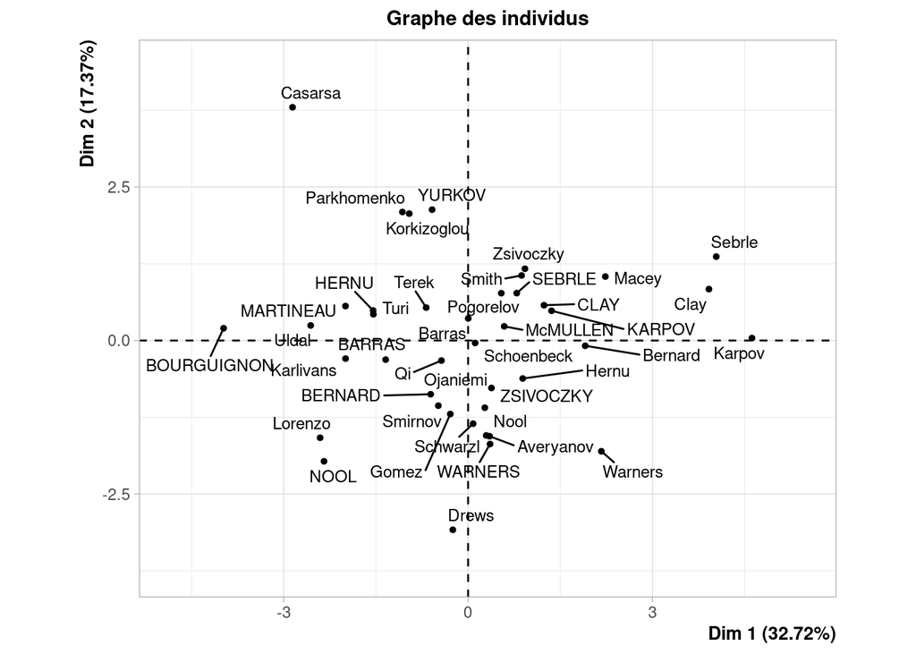

```r
plot(res, cex=0.8, invisible="quali", title="Graphe des individus")
```

Si on a beaucoup d’individus et que les libellés des individus ne sont pas explicites (des numéros par exemple), on peut supprimer les noms des libellés tout en laissant les points avec l’argument label=“none”.

```r
plot(res, cex=0.8, invisible="quali", label="none", title="Graphe des individus")
```

## Coloriage des individus en fonction de leur modalité

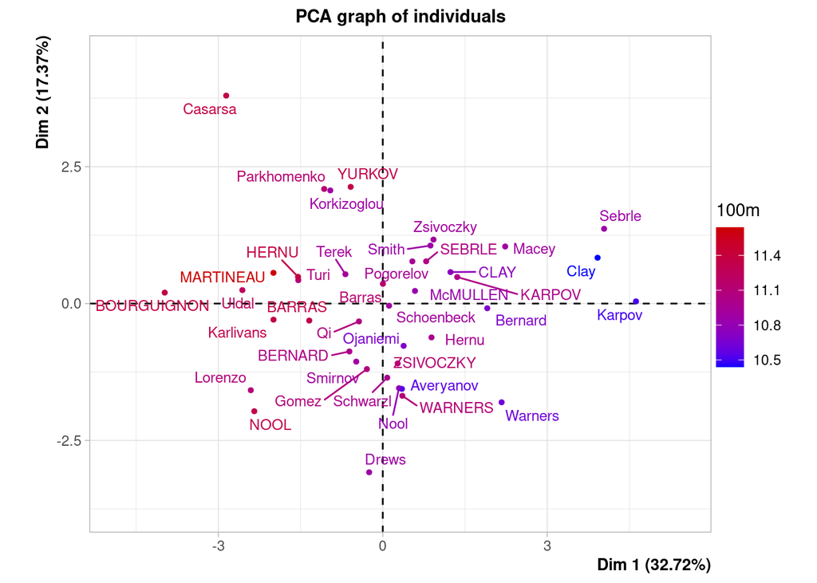

```r
plot(res, cex=0.8, habillage=1)
```

On aurait pu écrire :

```r
plot(res, cex=0.8, habillage=1)
```

# Ellipses de confiance autour des modalités

```r
plotellipses(res)
```

Si on a plusieurs variables qualitatives, on aura autant de graphes que de variables qualitatives. Avec sur chaque graphe, les ellipses de confiance des modalités de la variable qualitative en question.

# Graphes sur les dimensions 3 et 4

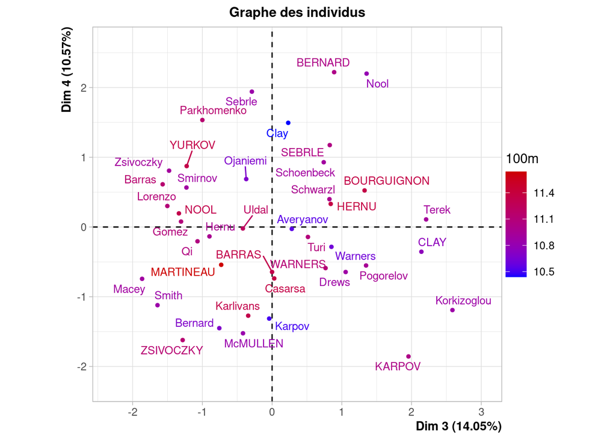

```r
plot(res, choix="ind", cex=0.8, habillage=1, title="Graphe des individus", axes=3:4)
```

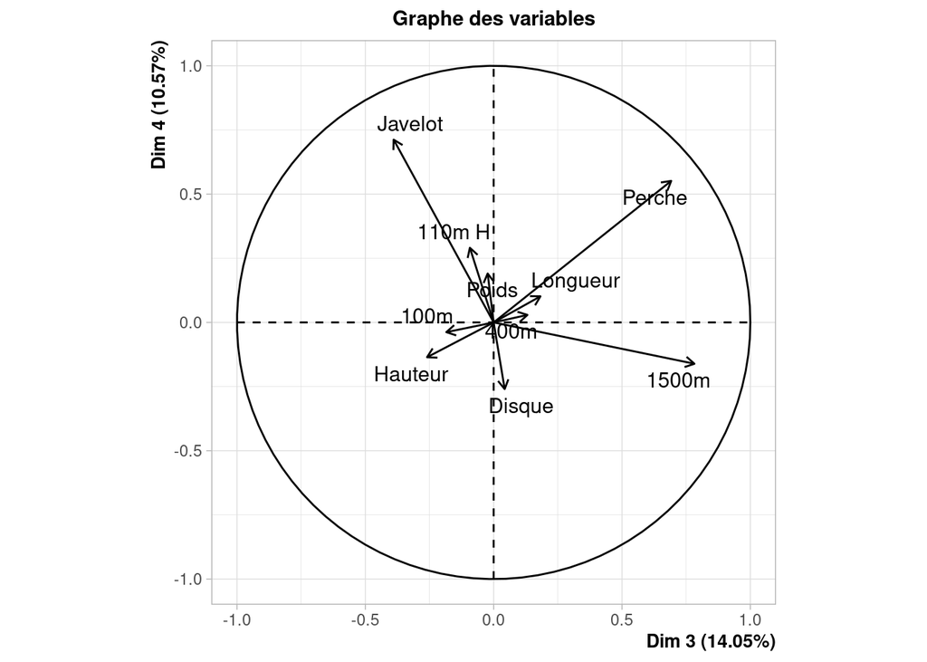

```r
plot(res, choix="var", title="Graphe des variables", axes=3:4)
```